# Antone Evans Jr. and Abilash Vanam

Predicting the Survival Rate of COVID-19 Patients

# 1.Data Exploration

##### str() summary()

```r
covid19 <- read.csv("covid19.csv")
str(covid19)
```

```
'data.frame':   1085 obs. of  21 variables:
 $ ï..id                : int  1 2 3 4 5 6 7 8 9 10 ...
 $ case_in_country      : int  NA NA NA NA NA NA NA NA NA NA ...
 $ reporting.date       : Factor w/ 43 levels "1/13/2020","1/15/2020",..: 4 4 5 5 5 5 5 5 5 5 ...
 $ X                    : logi  NA NA NA NA NA NA ...
 $ summary              : Factor w/ 967 levels "confirmed COVID-19 pneumonia patient No.11 in Tianjin: female, 55, symptom onset on 01/23/2020, hospitalized on"| __truncated__,..: 67 65 51 849 850 52 68 891 892 895 ...
 $ location             : Factor w/ 156 levels "Afghanistan",..: 117 114 155 130 130 25 118 14 14 14 ...
 $ country              : Factor w/ 38 levels "Afghanistan",..: 9 9 9 9 9 9 9 9 9 9 ...
 $ gender               : Factor w/ 2 levels "female","male": 2 1 2 1 2 1 2 2 2 2 ...
 $ age                  : num  66 56 46 60 58 44 34 37 39 56 ...
 $ symptom_onset        : Factor w/ 62 levels "1/10/2020","1/11/2020",..: 22 6 25 NA NA 6 2 5 30 7 ...
 $ If_onset_approximated: int  0 0 0 NA NA 0 0 0 0 0 ...
 $ hosp_visit_date      : Factor w/ 60 levels "","1/1/2020",..: 4 8 10 12 7 NA NA 13 7 13 ...
 $ exposure_start       : Factor w/ 37 levels "1/10/2020","1/11/2020",..: 28 NA NA NA NA NA NA 1 20 23 ...
 $ exposure_end         : Factor w/ 50 levels "1/10/2020","1/11/2020",..: 25 3 22 NA NA NA NA 2 25 7 ...
 $ visiting.Wuhan       : int  1 0 0 1 0 0 0 1 1 1 ...
 $ from.Wuhan           : int  0 1 1 0 0 1 1 0 0 0 ...
 $ death                : Factor w/ 14 levels "0","1","2/1/2020",..: 1 1 1 1 1 1 1 1 1 1 ...
 $ recovered            : Factor w/ 32 levels "0","1","1/15/2020",..: 1 1 1 1 1 1 1 1 1 1 ...
 $ symptom              : Factor w/ 109 levels "","chest discomfort",..: 1 1 1 1 1 1 1 1 1 1 ...
 $ source               : Factor w/ 85 levels "å¤®è§†æ–°é—»",..: 59 54 33 8 8 19 1 12 12 12 ...
 $ link                 : Factor w/ 490 levels "http://behdasht.gov.ir/news/%DA%A9%D8%B1%D9%88%D9%86%D8%A7+%D9%88%DB%8C%D8%B1%D9%88%D8%B3/199807/%D8%AF%D8%B1+%"| __truncated__,..: 5 470 11 39 39 6 40 4 4 4 ...
```

```r
summary(covid19)
```

```
     ï..id      case_in_country     reporting.date    X
 Min.   :   1   Min.   :   1.00   2/27/2020: 91    Mode:logical
 1st Qu.: 272   1st Qu.:  11.00   2/20/2020: 73    NA's:1085
 Median : 543   Median :  28.00   1/22/2020: 61
 Mean   : 543   Mean   :  48.84   2/26/2020: 54
 3rd Qu.: 814   3rd Qu.:  67.25   1/25/2020: 52
 Max.   :1085   Max.   :1443.00   (Other)  :753
                NA's   :197       NA's     :  1
                                                                                                        summary
 new confirmed COVID-19 patient in South Korea:                                                             :  22
 new confirmed COVID-19 patient in Germany: NRW                                                             :  14
 new confirmed COVID-19 patient in Iran: Qom                                                                :   9
 new confirmed COVID-19 patient in Kuwait: returned from Iran                                               :   8
 new confirmed COVID-19 patient in France: in contact with Briton who had been in Singapore and was positive:   5
 (Other)                                                                                                    :1022
 NA's                                                                                                       :   5
        location          country       gender         age          symptom_onset If_onset_approximated
 South Korea:112   China      :197   female:382   Min.   : 0.25   1/23/2020: 29   Min.   :0.0000
 Singapore  : 93   Japan      :190   male  :520   1st Qu.:35.00   1/25/2020: 22   1st Qu.:0.0000
 Hong Kong  : 80   South Korea:114   NA's  :183   Median :51.00   1/24/2020: 21   Median :0.0000
 Hokkaido   : 48   Hong Kong  : 94                Mean   :49.48   1/21/2020: 19   Mean   :0.0429
 Thailand   : 41   Singapore  : 93                3rd Qu.:64.00   1/30/2020: 19   3rd Qu.:0.0000
 Taiwan     : 34   Germany    : 54                Max.   :96.00   (Other)  :453   Max.   :1.0000
 (Other)    :677   (Other)    :343                NA's   :242     NA's     :522   NA's   :525
  hosp_visit_date   exposure_start    exposure_end visiting.Wuhan    from.Wuhan           death
 1/23/2020: 34    1/26/2020: 14    1/22/2020: 35   Min.   :0.000   Min.   :0.0000   0        :1022
 1/24/2020: 30    1/24/2020: 12    1/23/2020: 27   1st Qu.:0.000   1st Qu.:0.0000   1        :  42
 1/21/2020: 20    1/20/2020:  8    1/20/2020: 26   Median :0.000   Median :0.0000   2/23/2020:   4
 2/17/2020: 20    1/25/2020:  7    1/21/2020: 25   Mean   :0.177   Mean   :0.1443   2/26/2020:   3
 1/20/2020: 19    1/12/2020:  6    1/19/2020: 19   3rd Qu.:0.000   3rd Qu.:0.0000   2/19/2020:   2
 (Other)  :385    (Other)  : 81    (Other)  :209   Max.   :1.000   Max.   :1.0000   2/21/2020:   2
 NA's     :577    NA's     :957    NA's     :744                   NA's   :4        (Other)  :  10
      recovered                    symptom                             source
 0         :926                        :815   Ministry of Health          :179
 2/18/2020 : 13   fever                : 73   å¤®è§†æ–°é—»                :133
 2/19/2020 : 13   fever, cough         : 36   KCDC                        :103
 12/30/1899: 12   cough                : 14   Ministry of Health Singapore: 67
 2/12/2020 : 11   fever, malaise       :  7   Government HK               : 60
 2/21/2020 : 10   fever, cough, malaise:  6   Channel News Asia           : 51
 (Other)   :100   (Other)              :134   (Other)                     :492
                                                                                                                                                                                                                                                                                                            …
 https://www.mhlw.go.jp/stf/houdou/houdou_list_202002.html                                                                                                                                                                                                                                                  …
 https://www.mhlw.go.jp/stf/newpage_09713.html                                                                                                                                                                                                                                                              …
 https://www.mhlw.go.jp/stf/newpage_09652.html                                                                                                                                                                                                                                                              …
 https://www.moh.gov.sg/news-highlights/details/two-more-cases-discharged-two-new-cases-of-novel-coronavirus-infection-confirmed                                                                                                                                                                            …
 http://www.nhc.gov.cn/yjb/s3578/202001/5d19a4f6d3154b9fae328918ed2e3c8a.shtml                                                                                                                                                                                                                              …
 http://behdasht.gov.ir/news/%DA%A9%D8%B1%D9%88%D9%86%D8%A7+%D9%88%DB%8C%D8%B1%D9%88%D8%B3/199807/%D8%AF%D8%B1+%D8%B1%D9%88%D8%B2%D9%87%D8%A7%DB%8C+%DA%AF%D8%B0%D8%B4%D8%AA%D9%87+735+%D8%A8%DB%8C%D9%85%D8%A7%D8%B1+%D8%A8%D8%A7+%D8%B9%D9%84%D8%A7%D8%A6%D9%85+%D8%B4%D8%A8%D9%87+%D8%A2%D9%86%D9%81%D9%8…
 (Other)                                                                                                                                                                                                                                                                                                    …
```

##### Percentage of NAs in columns

Case_in_country : NA’s 18% Reporting.date : NA’s 0% X : NA’s 100% Summary : NA’s 0.46% Gender : NA’s 16% Age : NA’s 22% Symptom_onset : NA’s 48% If_onset_approximated : NA’s 48% Hosp_visit_date : NA’s 53% Exposure_start : NA’s 88% exposure_end : NA’s 69% from.Wuhan : NA’s 0.36%

```r
colMeans(is.na(covid19))
```

```
                ï..id       case_in_country        reporting.date                     X
          0.000000000           0.181566820           0.000921659           1.000000000
              summary              location               country                gender
          0.004608295           0.000000000           0.000000000           0.168663594
                  age         symptom_onset If_onset_approximated       hosp_visit_date
          0.223041475           0.481105991           0.483870968           0.531797235
       exposure_start          exposure_end        visiting.Wuhan            from.Wuhan
          0.882027650           0.685714286           0.000000000           0.003686636
                death             recovered               symptom                source
          0.000000000           0.000000000           0.000000000           0.000000000
                 link
          0.000000000
```

The dataset has 1085 observation of 21 variables. Lets see the names of all the 21 variables.

```r
names(covid19)
```

```
 [1] "ï..id"                 "case_in_country"       "reporting.date"        "X"
 [5] "summary"               "location"              "country"               "gender"
 [9] "age"                   "symptom_onset"         "If_onset_approximated" "hosp_visit_date"
[13] "exposure_start"        "exposure_end"          "visiting.Wuhan"        "from.Wuhan"
[17] "death"                 "recovered"             "symptom"               "source"
[21] "link"
```

From these 21 variables, we will remove some of the variables which are not required for the prediction of the target variable.

# Data Preprocessing

##### Remove case_in_country,summary, X, location, exposure_start, exposure_end, link and source

```r
covid19 = covid19[-21]
covid19 = covid19[-20]
covid19 = covid19[-14]
covid19 = covid19[-13]
covid19 = covid19[-6]
covid19 = covid19[-5]
covid19 = covid19[-4]
covid19 = covid19[-2]
```

```r
str(covid19)
```

```
'data.frame':   1085 obs. of  13 variables:
 $ ï..id                : int  1 2 3 4 5 6 7 8 9 10 ...
 $ reporting.date       : Factor w/ 43 levels "1/13/2020","1/15/2020",..: 4 4 5 5 5 5 5 5 5 5 ...
 $ country              : Factor w/ 38 levels "Afghanistan",..: 9 9 9 9 9 9 9 9 9 9 ...
 $ gender               : Factor w/ 2 levels "female","male": 2 1 2 1 2 1 2 2 2 2 ...
 $ age                  : num  66 56 46 60 58 44 34 37 39 56 ...
 $ symptom_onset        : Factor w/ 62 levels "1/10/2020","1/11/2020",..: 22 6 25 NA NA 6 2 5 30 7 ...
 $ If_onset_approximated: int  0 0 0 NA NA 0 0 0 0 0 ...
 $ hosp_visit_date      : Factor w/ 60 levels "","1/1/2020",..: 4 8 10 12 7 NA NA 13 7 13 ...
 $ visiting.Wuhan       : int  1 0 0 1 0 0 0 1 1 1 ...
 $ from.Wuhan           : int  0 1 1 0 0 1 1 0 0 0 ...
 $ death                : Factor w/ 14 levels "0","1","2/1/2020",..: 1 1 1 1 1 1 1 1 1 1 ...
 $ recovered            : Factor w/ 32 levels "0","1","1/15/2020",..: 1 1 1 1 1 1 1 1 1 1 ...
 $ symptom              : Factor w/ 109 levels "","chest discomfort",..: 1 1 1 1 1 1 1 1 1 1 ...
```

Now, we have 1085 observations and 13 variables.

##### Convert the sympton_onset, hosp_visit_date and reporting.date to Date columns. We will then find out the length of a symptom before reporting and the length of a hospital visit before reporting to the patient that they were COVID-19 positive.

```r
covid19$symptom_onset <- as.Date(covid19$symptom_onset, format = "%m/%d/%Y")
covid19$hosp_visit_date <- as.Date(covid19$hosp_visit_date, format = "%m/%d/%Y")
covid19$reporting.date <- as.Date(covid19$reporting.date, format = "%m/%d/%Y")
```

```r
covid19$symptomLength <- covid19$reporting.date - covid19$symptom_onset
covid19$reportingLength <- covid19$reporting.date - covid19$hosp_visit_date
covid19$symptomLength <- as.numeric(covid19$symptomLength)
covid19$reportingLength <- as.numeric(covid19$reportingLength)
```

```r
covid19 = covid19[-8]
covid19 = covid19[-6]
covid19 = covid19[-2]
```

##### If_onset_approzimated means if these patients contact with someone who has COVID-19. We will change all NAs to 0 assuming those patients weren’t.

```r
covid19$If_onset_approximated[is.na(covid19$If_onset_approximated)] <- 0
covid19$If_onset_approximated <- as.integer(covid19$If_onset_approximated)
```

##### Change death and recovered to binary variables

```r
covid19$death <- ifelse(covid19$death == 0, 0, 1)
covid19$recovered <- ifelse(covid19$recovered == 0, 0, 1)

covid19$death <- as.integer(covid19$death)
covid19$recovered <- as.integer(covid19$recovered)
```

##### Impute the age variable (as done in assignment 5) using the missforest method

We have to move variables with more than 53 variables caterogical levels. We removed symptom.

```r
names(covid19)
```

```
 [1] "ï..id"                 "country"               "gender"                "age"
 [5] "If_onset_approximated" "visiting.Wuhan"        "from.Wuhan"            "death"
 [9] "recovered"             "symptom"               "symptomLength"         "reportingLength"
```

```r
covid19DF = covid19
covid19DF = covid19DF[-10]
covid19DF = covid19DF[-8]
```

reporting.date (1), gender (183), age (242), from.Wuhan (4) symptomLength 522 and reportingLength 579 all have NAs

```r
summary(covid19)
```

```
     ï..id             country       gender         age        If_onset_approximated visiting.Wuhan
 Min.   :   1   China      :197   female:382   Min.   : 0.25   Min.   :0.00000       Min.   :0.000
 1st Qu.: 272   Japan      :190   male  :520   1st Qu.:35.00   1st Qu.:0.00000       1st Qu.:0.000
 Median : 543   South Korea:114   NA's  :183   Median :51.00   Median :0.00000       Median :0.000
 Mean   : 543   Hong Kong  : 94                Mean   :49.48   Mean   :0.02212       Mean   :0.177
 3rd Qu.: 814   Singapore  : 93                3rd Qu.:64.00   3rd Qu.:0.00000       3rd Qu.:0.000
 Max.   :1085   Germany    : 54                Max.   :96.00   Max.   :1.00000       Max.   :1.000
                (Other)    :343                NA's   :242
   from.Wuhan         death           recovered                       symptom    symptomLength
 Min.   :0.0000   Min.   :0.00000   Min.   :0.0000                        :815   Min.   : 0.000
 1st Qu.:0.0000   1st Qu.:0.00000   1st Qu.:0.0000   fever                : 73   1st Qu.: 3.000
 Median :0.0000   Median :0.00000   Median :0.0000   fever, cough         : 36   Median : 6.000
 Mean   :0.1443   Mean   :0.05806   Mean   :0.1465   cough                : 14   Mean   : 7.682
 3rd Qu.:0.0000   3rd Qu.:0.00000   3rd Qu.:0.0000   fever, malaise       :  7   3rd Qu.:11.000
 Max.   :1.0000   Max.   :1.00000   Max.   :1.0000   fever, cough, malaise:  6   Max.   :43.000
 NA's   :4                                           (Other)              :134   NA's   :522
 reportingLength
 Min.   : 0.000
 1st Qu.: 1.000
 Median : 3.000
 Mean   : 4.818
 3rd Qu.: 7.000
 Max.   :26.000
 NA's   :579
```

```r
library(missForest)
covid19.imp <- missForest(covid19DF)
```

```
  missForest iteration 1 in progress...
```

```
The response has five or fewer unique values.  Are you sure you want to do regression?
```

```
done!
  missForest iteration 2 in progress...
```

```
The response has five or fewer unique values.  Are you sure you want to do regression?
```

```
done!
  missForest iteration 3 in progress...
```

```
The response has five or fewer unique values.  Are you sure you want to do regression?
```

```
done!
  missForest iteration 4 in progress...
```

```
The response has five or fewer unique values.  Are you sure you want to do regression?
```

```
done!
  missForest iteration 5 in progress...
```

```
The response has five or fewer unique values.  Are you sure you want to do regression?
```

```
done!
```

```r
covid19.imp$ximp
```

| ï..id | country | gender | age | If_onset_approximated | visiting.Wuhan | from.Wuhan | recovered | symptomLength | reportingLength |
| --- | --- | --- | --- | --- | --- | --- | --- | --- | --- |
| 1 | China | male | 66.00000 | 0 | 1 | 0.00000000 | 0 | 17.000000 | 9.0000000 |
| 2 | China | female | 56.00000 | 0 | 0 | 1.00000000 | 0 | 5.000000 | 5.0000000 |
| 3 | China | male | 46.00000 | 0 | 0 | 1.00000000 | 0 | 17.000000 | 4.0000000 |
| 4 | China | female | 60.00000 | 0 | 1 | 0.00000000 | 0 | 7.997573 | 2.0000000 |
| 5 | China | male | 58.00000 | 0 | 0 | 0.00000000 | 0 | 12.465482 | 7.0000000 |
| 6 | China | female | 44.00000 | 0 | 0 | 1.00000000 | 0 | 6.000000 | 3.2126767 |
| 7 | China | male | 34.00000 | 0 | 0 | 1.00000000 | 0 | 10.000000 | 6.7424735 |
| 8 | China | male | 37.00000 | 0 | 1 | 0.00000000 | 0 | 7.000000 | 1.0000000 |
| 9 | China | male | 39.00000 | 0 | 1 | 0.00000000 | 0 | 12.000000 | 7.0000000 |
| 10 | China | male | 56.00000 | 0 | 1 | 0.00000000 | 0 | 5.000000 | 1.0000000 |

[output cut: 990 more lines]

```r
covid19.imp$OOBerror
```

```
     NRMSE        PFC
0.02708344 0.20288248
```

Adding back to features that were removed before missForesting

```r
covid19.imp$ximp$age <- as.integer(covid19.imp$ximp$age)
covid19.imp$ximp$from.Wuhan <- as.integer(covid19.imp$ximp$from.Wuhan)

symptom = covid19$symptom
death = covid19$death

NEWcovid19 = cbind(covid19.imp$ximp,symptom)
NEWcovid19 = cbind(NEWcovid19,death)
summary(NEWcovid19)
```

```
     ï..id             country       gender         age        If_onset_approximated visiting.Wuhan
 Min.   :   1   China      :197   female:461   Min.   : 0.00   Min.   :0.00000       Min.   :0.000
 1st Qu.: 272   Japan      :190   male  :624   1st Qu.:37.00   1st Qu.:0.00000       1st Qu.:0.000
 Median : 543   South Korea:114                Median :47.00   Median :0.00000       Median :0.000
 Mean   : 543   Hong Kong  : 94                Mean   :48.39   Mean   :0.02212       Mean   :0.177
 3rd Qu.: 814   Singapore  : 93                3rd Qu.:58.00   3rd Qu.:0.00000       3rd Qu.:0.000
 Max.   :1085   Germany    : 54                Max.   :96.00   Max.   :1.00000       Max.   :1.000
                (Other)    :343
   from.Wuhan       recovered      symptomLength    reportingLength                   symptom
 Min.   :0.0000   Min.   :0.0000   Min.   : 0.000   Min.   : 0.000                        :815
 1st Qu.:0.0000   1st Qu.:0.0000   1st Qu.: 4.684   1st Qu.: 2.000   fever                : 73
 Median :0.0000   Median :0.0000   Median : 6.400   Median : 3.207   fever, cough         : 36
 Mean   :0.1438   Mean   :0.1465   Mean   : 7.215   Mean   : 4.263   cough                : 14
 3rd Qu.:0.0000   3rd Qu.:0.0000   3rd Qu.: 8.546   3rd Qu.: 5.026   fever, malaise       :  7
 Max.   :1.0000   Max.   :1.0000   Max.   :43.000   Max.   :26.000   fever, cough, malaise:  6
                                                                     (Other)              :134
     death
 Min.   :0.00000
 1st Qu.:0.00000
 Median :0.00000
 Mean   :0.05806
 3rd Qu.:0.00000
 Max.   :1.00000
```

##### Create a separate binary variable for each symptom appearing in the “symptom” column.

```r
NEWcovid19$symptom[NEWcovid19$symptom==""] <- NA
levels <- levels(NEWcovid19$symptom)
levels[length(levels) + 1] <- "none"
NEWcovid19$symptom <- factor(NEWcovid19$symptom, levels = levels)
NEWcovid19$symptom[is.na(NEWcovid19$symptom)] <- "none"
```

```r
NEWcovid19$symptom <- gsub("chill", "chills", NEWcovid19$symptom)
NEWcovid19$symptom <- gsub("cough", "coughing", NEWcovid19$symptom)
NEWcovid19$symptom <- gsub("difficult in breathing", "difficulty breathing", NEWcovid19$symptom)
NEWcovid19$symptom <- gsub("feaver", "fever", NEWcovid19$symptom)
NEWcovid19$symptom <- gsub("feve\\\\", "fever", NEWcovid19$symptom)
NEWcovid19$symptom <- gsub("flu", "flu symptoms", NEWcovid19$symptom)
NEWcovid19$symptom <- gsub("myalgias", "myalgia", NEWcovid19$symptom)
NEWcovid19$symptom <- gsub("shortness of breath", "dyspnea", NEWcovid19$symptom)
NEWcovid19$symptom <- gsub("breathlessness", "dyspnea", NEWcovid19$symptom)
NEWcovid19$symptom <- gsub("aching muscles", "muscle aches", NEWcovid19$symptom)
NEWcovid19$symptom <- gsub("muscle aches", "myalgia", NEWcovid19$symptom)
NEWcovid19$symptom <- gsub("muscle pain", "myalgia", NEWcovid19$symptom)
NEWcovid19$symptom <- gsub("sore body", "myalgia", NEWcovid19$symptom)
NEWcovid19$symptom <- gsub("chest pain", "chest discomfort", NEWcovid19$symptom)
NEWcovid19$symptom <- gsub("runny nose", "nasal discharge", NEWcovid19$symptom)
NEWcovid19$symptom <- gsub("coughing with sputum", "sputum", NEWcovid19$symptom)
NEWcovid19$symptom <- gsub("tired", "fatigue", NEWcovid19$symptom)
NEWcovid19$symptom <- gsub("high fever", "fever", NEWcovid19$symptom)
NEWcovid19$symptom <- gsub("mild fever", "fever", NEWcovid19$symptom)
NEWcovid19$symptom <- gsub("mild coughing", "coughing", NEWcovid19$symptom)
```

```r
NEWcovid19$symptom <- gsub("chillss", "chills", NEWcovid19$symptom)
NEWcovid19$symptom <- gsub("coughinging", "coughing", NEWcovid19$symptom)
NEWcovid19$symptom <- gsub("fever", "fever (mild to sever)", NEWcovid19$symptom)
NEWcovid19$symptom <- gsub("coughing", "coughing (mild to sever)", NEWcovid19$symptom)
NEWcovid19$symptom <- gsub("flu symptoms symptoms", "flu symptoms", NEWcovid19$symptom)
NEWcovid19$symptom <- gsub("reflu symptomsx", "reflux", NEWcovid19$symptom)
NEWcovid19$symptom <- gsub("heavy head", "headache", NEWcovid19$symptom)
```

```r
length(unique(unlist(strsplit(as.character(NEWcovid19$symptom),', '))))
```

```
[1] 32
```

```r
unique(unlist(strsplit(as.character(NEWcovid19$symptom),', ')))
```

```
 [1] "none"                     "fever (mild to sever)"    "coughing (mild to sever)"
 [4] "difficulty breathing"     "chills"                   "joint pain"
 [7] "throat pain"              "nasal discharge"          "fatigue"
[10] "abdominal pain"           "diarrhea"                 "cold"
[13] "pneumonia"                "vomiting"                 "loss of appetite"
[16] "malaise"                  "headache"                 "sputum"
[19] "myalgia"                  "sore throat"              "dyspnea"
[22] "nausea"                   "respiratory distress"     "throat discomfort"
[25] "sneeze"                   "chest discomfort"         "thirst"
[28] "flu symptoms"             "muscle cramps"            "reflux"
[31] "physical discomfort"      "itchy throat"
```

```r
spl_letters = strsplit(as.character(NEWcovid19[["symptom"]]), ", ", fixed = TRUE)
uniq = unique(unlist(spl_letters), use.names = FALSE)

c19 <- data.frame(NEWcovid19,
           setNames(data.frame(t(vapply(spl_letters, function(x) +(uniq %in% x), seq_along(uniq)))), paste0("Symptom_", uniq))
)
```

Removing the symptom variable.

```r
c19 <- c19[-11]
c19 <- c19[-1]
```

Lookup the data.

```r
summary(c19)
```

```
        country       gender         age        If_onset_approximated visiting.Wuhan    from.Wuhan
 China      :197   female:461   Min.   : 0.00   Min.   :0.00000       Min.   :0.000   Min.   :0.0000
 Japan      :190   male  :624   1st Qu.:37.00   1st Qu.:0.00000       1st Qu.:0.000   1st Qu.:0.0000
 South Korea:114                Median :47.00   Median :0.00000       Median :0.000   Median :0.0000
 Hong Kong  : 94                Mean   :48.39   Mean   :0.02212       Mean   :0.177   Mean   :0.1438
 Singapore  : 93                3rd Qu.:58.00   3rd Qu.:0.00000       3rd Qu.:0.000   3rd Qu.:0.0000
 Germany    : 54                Max.   :96.00   Max.   :1.00000       Max.   :1.000   Max.   :1.0000
 (Other)    :343
   recovered      symptomLength    reportingLength      death          Symptom_none
 Min.   :0.0000   Min.   : 0.000   Min.   : 0.000   Min.   :0.00000   Min.   :0.0000
 1st Qu.:0.0000   1st Qu.: 4.684   1st Qu.: 2.000   1st Qu.:0.00000   1st Qu.:1.0000
 Median :0.0000   Median : 6.400   Median : 3.207   Median :0.00000   Median :1.0000
 Mean   :0.1465   Mean   : 7.215   Mean   : 4.263   Mean   :0.05806   Mean   :0.7512
 3rd Qu.:0.0000   3rd Qu.: 8.546   3rd Qu.: 5.026   3rd Qu.:0.00000   3rd Qu.:1.0000
 Max.   :1.0000   Max.   :43.000   Max.   :26.000   Max.   :1.00000   Max.   :1.0000

 Symptom_fever..mild.to.sever. Symptom_coughing..mild.to.sever. Symptom_difficulty.breathing
 Min.   :0.0000                Min.   :0.0000                   Min.   :0.000000
 1st Qu.:0.0000                1st Qu.:0.0000                   1st Qu.:0.000000
 Median :0.0000                Median :0.0000                   Median :0.000000
 Mean   :0.1899                Mean   :0.1069                   Mean   :0.004608
 3rd Qu.:0.0000                3rd Qu.:0.0000                   3rd Qu.:0.000000
 Max.   :1.0000                Max.   :1.0000                   Max.   :1.000000

 Symptom_chills   Symptom_joint.pain Symptom_throat.pain Symptom_nasal.discharge Symptom_fatigue
 Min.   :0.0000   Min.   :0.000000   Min.   :0.000000    Min.   :0.00000         Min.   :0.00000
 1st Qu.:0.0000   1st Qu.:0.000000   1st Qu.:0.000000    1st Qu.:0.00000         1st Qu.:0.00000
 Median :0.0000   Median :0.000000   Median :0.000000    Median :0.00000         Median :0.00000
 Mean   :0.0129   Mean   :0.008295   Mean   :0.001843    Mean   :0.01106         Mean   :0.01106
 3rd Qu.:0.0000   3rd Qu.:0.000000   3rd Qu.:0.000000    3rd Qu.:0.00000         3rd Qu.:0.00000
 Max.   :1.0000   Max.   :1.000000   Max.   :1.000000    Max.   :1.00000         Max.   :1.00000

 Symptom_abdominal.pain Symptom_diarrhea    Symptom_cold      Symptom_pneumonia  Symptom_vomiting
 Min.   :0.0000000      Min.   :0.000000   Min.   :0.000000   Min.   :0.000000   Min.   :0.00000
 1st Qu.:0.0000000      1st Qu.:0.000000   1st Qu.:0.000000   1st Qu.:0.000000   1st Qu.:0.00000
 Median :0.0000000      Median :0.000000   Median :0.000000   Median :0.000000   Median :0.00000
 Mean   :0.0009217      Mean   :0.009217   Mean   :0.001843   Mean   :0.002765   Mean   :0.00553
 3rd Qu.:0.0000000      3rd Qu.:0.000000   3rd Qu.:0.000000   3rd Qu.:0.000000   3rd Qu.:0.00000
 Max.   :1.0000000      Max.   :1.000000   Max.   :1.000000   Max.   :1.000000   Max.   :1.00000

```

[output cut: 24 more lines]

```
 Symptom_flu.symptoms Symptom_muscle.cramps Symptom_reflux      Symptom_physical.discomfort
 Min.   :0.000000     Min.   :0.0000000     Min.   :0.0000000   Min.   :0.0000000
 1st Qu.:0.000000     1st Qu.:0.0000000     1st Qu.:0.0000000   1st Qu.:0.0000000
 Median :0.000000     Median :0.0000000     Median :0.0000000   Median :0.0000000
 Mean   :0.001843     Mean   :0.0009217     Mean   :0.0009217   Mean   :0.0009217
 3rd Qu.:0.000000     3rd Qu.:0.0000000     3rd Qu.:0.0000000   3rd Qu.:0.0000000
 Max.   :1.000000     Max.   :1.0000000     Max.   :1.0000000   Max.   :1.0000000

 Symptom_itchy.throat
 Min.   :0.0000000
 1st Qu.:0.0000000
 Median :0.0000000
 Mean   :0.0009217
 3rd Qu.:0.0000000
 Max.   :1.0000000
```

# Further Data Exploration

Converting the death column into caterogical form from binary.

```r
survivalORnot = ifelse(c19$death == 1, "death", "survival")
c19exploreData = cbind(survivalORnot, c19)
c19exploreData = c19exploreData[-11]
c19exploreData$If_onset_approximated = ifelse(c19exploreData$If_onset_approximated == 1, "yes", "no")
c19exploreData$visiting.Wuhan = ifelse(c19exploreData$visiting.Wuhan == 1, "yes", "no")
c19exploreData$from.Wuhan = ifelse(c19exploreData$from.Wuhan == 1, "yes", "no")
c19exploreData$recovered = ifelse(c19exploreData$recovered == 1, "yes", "no")
c19exploreData$Symptom_none = ifelse(c19exploreData$Symptom_none == 1, "yes", "no")
c19exploreData$Symptom_fever..mild.to.sever. = ifelse(c19exploreData$Symptom_fever..mild.to.sever. == 1, "yes", "no")
c19exploreData$Symptom_coughing..mild.to.sever. = ifelse(c19exploreData$Symptom_coughing..mild.to.sever. == 1, "yes", "no")
c19exploreData$Symptom_difficulty.breathing = ifelse(c19exploreData$Symptom_difficulty.breathing == 1, "yes", "no")
c19exploreData$Symptom_chills = ifelse(c19exploreData$Symptom_chills == 1, "yes", "no")
c19exploreData$Symptom_joint.pain = ifelse(c19exploreData$Symptom_joint.pain == 1, "yes", "no")
c19exploreData$Symptom_throat.pain = ifelse(c19exploreData$Symptom_throat.pain == 1, "yes", "no")
c19exploreData$Symptom_nasal.discharge = ifelse(c19exploreData$Symptom_nasal.discharge == 1, "yes", "no")
c19exploreData$Symptom_fatigue = ifelse(c19exploreData$Symptom_fatigue == 1, "yes", "no")
c19exploreData$Symptom_abdominal.pain = ifelse(c19exploreData$Symptom_abdominal.pain == 1, "yes", "no")
c19exploreData$Symptom_diarrhea = ifelse(c19exploreData$Symptom_diarrhea == 1, "yes", "no")
c19exploreData$Symptom_cold = ifelse(c19exploreData$Symptom_cold == 1, "yes", "no")
c19exploreData$Symptom_pneumonia = ifelse(c19exploreData$Symptom_pneumonia == 1, "yes", "no")
c19exploreData$Symptom_vomiting = ifelse(c19exploreData$Symptom_vomiting == 1, "yes", "no")
c19exploreData$Symptom_loss.of.appetite = ifelse(c19exploreData$Symptom_loss.of.appetite == 1, "yes", "no")
c19exploreData$Symptom_malaise = ifelse(c19exploreData$Symptom_malaise == 1, "yes", "no")
c19exploreData$Symptom_headache = ifelse(c19exploreData$Symptom_headache == 1, "yes", "no")
c19exploreData$Symptom_sputum = ifelse(c19exploreData$Symptom_sputum == 1, "yes", "no")
c19exploreData$Symptom_myalgia = ifelse(c19exploreData$Symptom_myalgia == 1, "yes", "no")
c19exploreData$Symptom_sore.throat = ifelse(c19exploreData$Symptom_sore.throat == 1, "yes", "no")
c19exploreData$Symptom_dyspnea = ifelse(c19exploreData$Symptom_dyspnea == 1, "yes", "no")
c19exploreData$Symptom_nausea = ifelse(c19exploreData$Symptom_nausea == 1, "yes", "no")
c19exploreData$Symptom_respiratory.distress = ifelse(c19exploreData$Symptom_respiratory.distress == 1, "yes", "no")
c19exploreData$Symptom_throat.discomfort = ifelse(c19exploreData$Symptom_throat.discomfort == 1, "yes", "no")
c19exploreData$Symptom_thirst = ifelse(c19exploreData$Symptom_thirst == 1, "yes", "no")
c19exploreData$Symptom_sneeze = ifelse(c19exploreData$Symptom_sneeze == 1, "yes", "no")
c19exploreData$Symptom_chest.discomfort = ifelse(c19exploreData$Symptom_chest.discomfort == 1, "yes", "no")
c19exploreData$Symptom_flu.symptoms = ifelse(c19exploreData$Symptom_flu.symptoms == 1, "yes", "no")
c19exploreData$Symptom_muscle.cramps = ifelse(c19exploreData$Symptom_muscle.cramps == 1, "yes", "no")
c19exploreData$Symptom_reflux = ifelse(c19exploreData$Symptom_reflux == 1, "yes", "no")
c19exploreData$Symptom_physical.discomfort = ifelse(c19exploreData$Symptom_physical.discomfort == 1, "yes", "no")
c19exploreData$Symptom_itchy.throat = ifelse(c19exploreData$Symptom_itchy.throat == 1, "yes", "no")
```

##### Which variables are associated with “death”.

##### Exploring Categorical Variables

```r
library(gmodels)
library(ggplot2)
attach(c19exploreData)
CrossTable(x=country, y=survivalORnot, chisq = TRUE)
```

```
Chi-squared approximation may be incorrect
```

```
   Cell Contents
|-------------------------|
|                       N |
| Chi-square contribution |
|           N / Row Total |
|           N / Col Total |
|         N / Table Total |
|-------------------------|


Total Observations in Table:  1085


             | survivalORnot
     country |     death |  survival | Row Total |
-------------|-----------|-----------|-----------|
 Afghanistan |         0 |         1 |         1 |
             |     0.058 |     0.004 |           |
             |     0.000 |     1.000 |     0.001 |
             |     0.000 |     0.001 |           |
             |     0.000 |     0.001 |           |
-------------|-----------|-----------|-----------|
     Algeria |         0 |         1 |         1 |
             |     0.058 |     0.004 |           |
             |     0.000 |     1.000 |     0.001 |
             |     0.000 |     0.001 |           |
             |     0.000 |     0.001 |           |
-------------|-----------|-----------|-----------|
   Australia |         0 |        15 |        15 |
             |     0.871 |     0.054 |           |
             |     0.000 |     1.000 |     0.014 |
             |     0.000 |     0.015 |           |
             |     0.000 |     0.014 |           |
-------------|-----------|-----------|-----------|
     Austria |         0 |         2 |         2 |
             |     0.116 |     0.007 |           |
             |     0.000 |     1.000 |     0.002 |
             |     0.000 |     0.002 |           |
             |     0.000 |     0.002 |           |
-------------|-----------|-----------|-----------|
```

[output cut: 200 more lines]

```
             |     0.000 |     1.000 |     0.015 |
             |     0.000 |     0.016 |           |
             |     0.000 |     0.015 |           |
-------------|-----------|-----------|-----------|
Column Total |        63 |      1022 |      1085 |
             |     0.058 |     0.942 |           |
-------------|-----------|-----------|-----------|


Statistics for All Table Factors


Pearson's Chi-squared test
------------------------------------------------------------
Chi^2 =  115.2177     d.f. =  37     p =  5.841393e-10
```

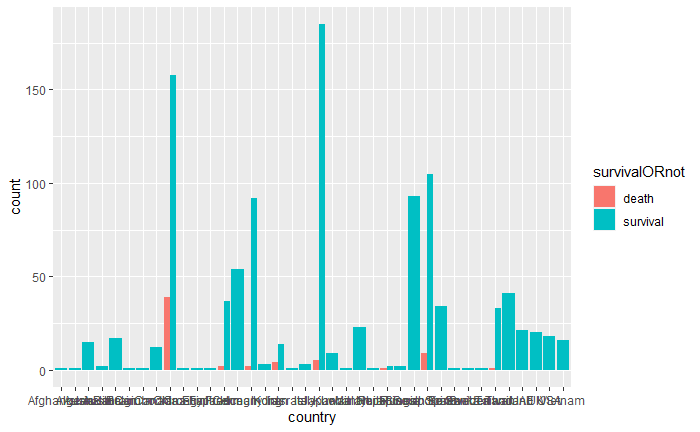

```r
ggplot(c19exploreData, aes(country, ..count..)) + geom_bar(aes(fill = survivalORnot), position = "dodge")
```

```r
CrossTable(x=gender, y=survivalORnot, chisq = TRUE)
```

```
   Cell Contents
|-------------------------|
|                       N |
| Chi-square contribution |
|           N / Row Total |
|           N / Col Total |
|         N / Table Total |
|-------------------------|


Total Observations in Table:  1085


             | survivalORnot
      gender |     death |  survival | Row Total |
-------------|-----------|-----------|-----------|
      female |        14 |       447 |       461 |
             |     6.090 |     0.375 |           |
             |     0.030 |     0.970 |     0.425 |
             |     0.222 |     0.437 |           |
             |     0.013 |     0.412 |           |
-------------|-----------|-----------|-----------|
        male |        49 |       575 |       624 |
             |     4.499 |     0.277 |           |
             |     0.079 |     0.921 |     0.575 |
             |     0.778 |     0.563 |           |
             |     0.045 |     0.530 |           |
-------------|-----------|-----------|-----------|
Column Total |        63 |      1022 |      1085 |
             |     0.058 |     0.942 |           |
-------------|-----------|-----------|-----------|


Statistics for All Table Factors


Pearson's Chi-squared test
------------------------------------------------------------
Chi^2 =  11.24192     d.f. =  1     p =  0.0007997044

Pearson's Chi-squared test with Yates' continuity correction
------------------------------------------------------------
Chi^2 =  10.37867     d.f. =  1     p =  0.001274798
```

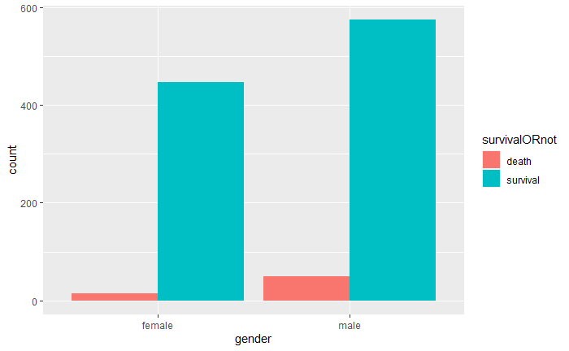

```r
ggplot(c19exploreData, aes(gender, ..count..)) + geom_bar(aes(fill = survivalORnot), position = "dodge")
```

```r
CrossTable(x=If_onset_approximated, y=survivalORnot, chisq = TRUE)
```

```
Chi-squared approximation may be incorrectChi-squared approximation may be incorrect
```

```
   Cell Contents
|-------------------------|
|                       N |
| Chi-square contribution |
|           N / Row Total |
|           N / Col Total |
|         N / Table Total |
|-------------------------|


Total Observations in Table:  1085


                      | survivalORnot
If_onset_approximated |     death |  survival | Row Total |
----------------------|-----------|-----------|-----------|
                   no |        61 |      1000 |      1061 |
                      |     0.006 |     0.000 |           |
                      |     0.057 |     0.943 |     0.978 |
                      |     0.968 |     0.978 |           |
                      |     0.056 |     0.922 |           |
----------------------|-----------|-----------|-----------|
                  yes |         2 |        22 |        24 |
                      |     0.264 |     0.016 |           |
                      |     0.083 |     0.917 |     0.022 |
                      |     0.032 |     0.022 |           |
                      |     0.002 |     0.020 |           |
----------------------|-----------|-----------|-----------|
         Column Total |        63 |      1022 |      1085 |
                      |     0.058 |     0.942 |           |
----------------------|-----------|-----------|-----------|


Statistics for All Table Factors


Pearson's Chi-squared test
------------------------------------------------------------
Chi^2 =  0.2865256     d.f. =  1     p =  0.5924556

Pearson's Chi-squared test with Yates' continuity correction
------------------------------------------------------------
Chi^2 =  0.008828271     d.f. =  1     p =  0.9251418
```

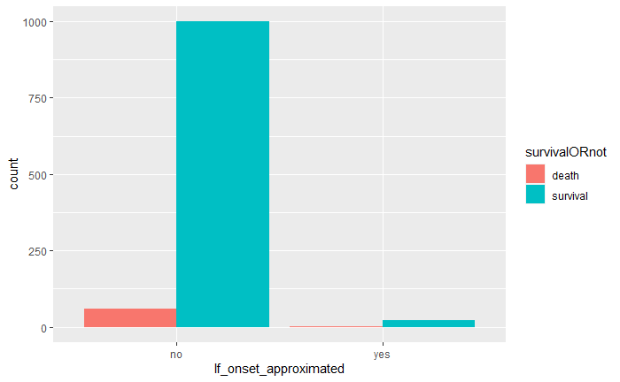

```r
ggplot(c19exploreData, aes(If_onset_approximated, ..count..)) + geom_bar(aes(fill = survivalORnot), position = "dodge")
```

```r
CrossTable(x=visiting.Wuhan, y=survivalORnot, chisq = TRUE)
```

```
   Cell Contents
|-------------------------|
|                       N |
| Chi-square contribution |
|           N / Row Total |
|           N / Col Total |
|         N / Table Total |
|-------------------------|


Total Observations in Table:  1085


               | survivalORnot
visiting.Wuhan |     death |  survival | Row Total |
---------------|-----------|-----------|-----------|
            no |        62 |       831 |       893 |
               |     1.986 |     0.122 |           |
               |     0.069 |     0.931 |     0.823 |
               |     0.984 |     0.813 |           |
               |     0.057 |     0.766 |           |
---------------|-----------|-----------|-----------|
           yes |         1 |       191 |       192 |
               |     9.238 |     0.569 |           |
               |     0.005 |     0.995 |     0.177 |
               |     0.016 |     0.187 |           |
               |     0.001 |     0.176 |           |
---------------|-----------|-----------|-----------|
  Column Total |        63 |      1022 |      1085 |
               |     0.058 |     0.942 |           |
---------------|-----------|-----------|-----------|


Statistics for All Table Factors


Pearson's Chi-squared test
------------------------------------------------------------
Chi^2 =  11.91624     d.f. =  1     p =  0.0005564678

Pearson's Chi-squared test with Yates' continuity correction
------------------------------------------------------------
Chi^2 =  10.77096     d.f. =  1     p =  0.001031049
```

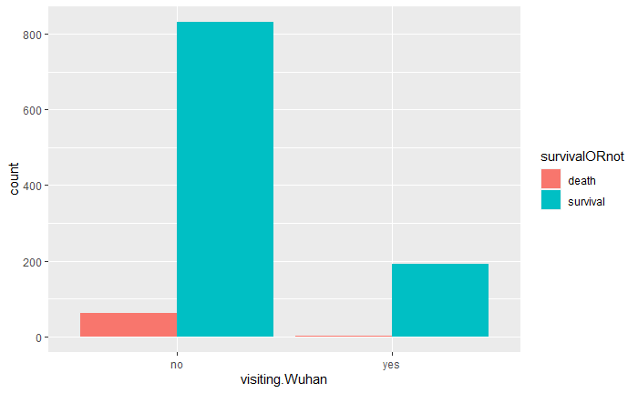

```r
ggplot(c19exploreData, aes(visiting.Wuhan, ..count..)) + geom_bar(aes(fill = survivalORnot), position = "dodge")
```

```r
CrossTable(x=from.Wuhan, y=survivalORnot, chisq = TRUE)
```

```
   Cell Contents
|-------------------------|
|                       N |
| Chi-square contribution |
|           N / Row Total |
|           N / Col Total |
|         N / Table Total |
|-------------------------|


Total Observations in Table:  1085


             | survivalORnot
  from.Wuhan |     death |  survival | Row Total |
-------------|-----------|-----------|-----------|
          no |        29 |       900 |       929 |
             |    11.533 |     0.711 |           |
             |     0.031 |     0.969 |     0.856 |
             |     0.460 |     0.881 |           |
             |     0.027 |     0.829 |           |
-------------|-----------|-----------|-----------|
         yes |        34 |       122 |       156 |
             |    68.679 |     4.234 |           |
             |     0.218 |     0.782 |     0.144 |
             |     0.540 |     0.119 |           |
             |     0.031 |     0.112 |           |
-------------|-----------|-----------|-----------|
Column Total |        63 |      1022 |      1085 |
             |     0.058 |     0.942 |           |
-------------|-----------|-----------|-----------|


Statistics for All Table Factors


Pearson's Chi-squared test
------------------------------------------------------------
Chi^2 =  85.15649     d.f. =  1     p =  2.756613e-20

Pearson's Chi-squared test with Yates' continuity correction
------------------------------------------------------------
Chi^2 =  81.77652     d.f. =  1     p =  1.523779e-19
```

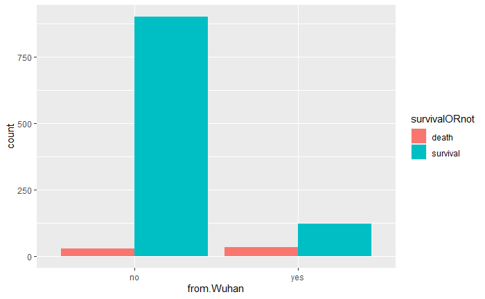

```r
ggplot(c19exploreData, aes(from.Wuhan, ..count..)) + geom_bar(aes(fill = survivalORnot), position = "dodge")
```

```r
CrossTable(x=recovered, y=survivalORnot, chisq = TRUE)
```

```
   Cell Contents
|-------------------------|
|                       N |
| Chi-square contribution |
|           N / Row Total |
|           N / Col Total |
|         N / Table Total |
|-------------------------|


Total Observations in Table:  1085


             | survivalORnot
   recovered |     death |  survival | Row Total |
-------------|-----------|-----------|-----------|
          no |        63 |       863 |       926 |
             |     1.585 |     0.098 |           |
             |     0.068 |     0.932 |     0.853 |
             |     1.000 |     0.844 |           |
             |     0.058 |     0.795 |           |
-------------|-----------|-----------|-----------|
         yes |         0 |       159 |       159 |
             |     9.232 |     0.569 |           |
             |     0.000 |     1.000 |     0.147 |
             |     0.000 |     0.156 |           |
             |     0.000 |     0.147 |           |
-------------|-----------|-----------|-----------|
Column Total |        63 |      1022 |      1085 |
             |     0.058 |     0.942 |           |
-------------|-----------|-----------|-----------|


Statistics for All Table Factors


Pearson's Chi-squared test
------------------------------------------------------------
Chi^2 =  11.48433     d.f. =  1     p =  0.0007018556

Pearson's Chi-squared test with Yates' continuity correction
------------------------------------------------------------
Chi^2 =  10.27408     d.f. =  1     p =  0.001349124
```

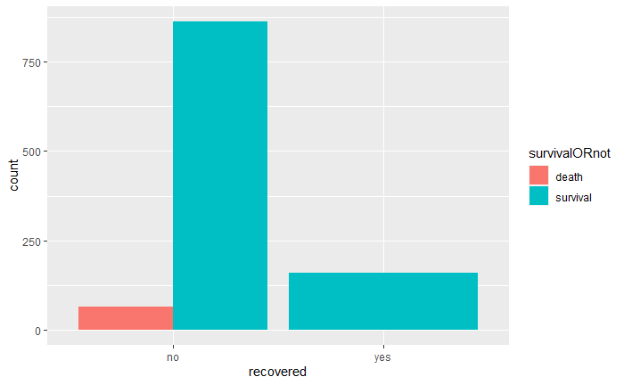

```r
ggplot(c19exploreData, aes(recovered, ..count..)) + geom_bar(aes(fill = survivalORnot), position = "dodge")
```

```r
CrossTable(x=Symptom_none, y=survivalORnot, chisq = TRUE)
```

```
   Cell Contents
|-------------------------|
|                       N |
| Chi-square contribution |
|           N / Row Total |
|           N / Col Total |
|         N / Table Total |
|-------------------------|


Total Observations in Table:  1085


             | survivalORnot
Symptom_none |     death |  survival | Row Total |
-------------|-----------|-----------|-----------|
          no |         9 |       261 |       270 |
             |     2.844 |     0.175 |           |
             |     0.033 |     0.967 |     0.249 |
             |     0.143 |     0.255 |           |
             |     0.008 |     0.241 |           |
-------------|-----------|-----------|-----------|
         yes |        54 |       761 |       815 |
             |     0.942 |     0.058 |           |
             |     0.066 |     0.934 |     0.751 |
             |     0.857 |     0.745 |           |
             |     0.050 |     0.701 |           |
-------------|-----------|-----------|-----------|
Column Total |        63 |      1022 |      1085 |
             |     0.058 |     0.942 |           |
-------------|-----------|-----------|-----------|


Statistics for All Table Factors


Pearson's Chi-squared test
------------------------------------------------------------
Chi^2 =  4.019701     d.f. =  1     p =  0.0449717

Pearson's Chi-squared test with Yates' continuity correction
------------------------------------------------------------
Chi^2 =  3.440254     d.f. =  1     p =  0.06362589
```

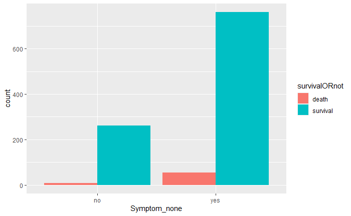

```r
ggplot(c19exploreData, aes(Symptom_none, ..count..)) + geom_bar(aes(fill = survivalORnot), position = "dodge")
```

```r
CrossTable(x=Symptom_fever..mild.to.sever., y=survivalORnot, chisq = TRUE)
```

```
   Cell Contents
|-------------------------|
|                       N |
| Chi-square contribution |
|           N / Row Total |
|           N / Col Total |
|         N / Table Total |
|-------------------------|


Total Observations in Table:  1085


                              | survivalORnot
Symptom_fever..mild.to.sever. |     death |  survival | Row Total |
------------------------------|-----------|-----------|-----------|
                           no |        59 |       820 |       879 |
                              |     1.242 |     0.077 |           |
                              |     0.067 |     0.933 |     0.810 |
                              |     0.937 |     0.802 |           |
                              |     0.054 |     0.756 |           |
------------------------------|-----------|-----------|-----------|
                          yes |         4 |       202 |       206 |
                              |     5.299 |     0.327 |           |
                              |     0.019 |     0.981 |     0.190 |
                              |     0.063 |     0.198 |           |
                              |     0.004 |     0.186 |           |
------------------------------|-----------|-----------|-----------|
                 Column Total |        63 |      1022 |      1085 |
                              |     0.058 |     0.942 |           |
------------------------------|-----------|-----------|-----------|


Statistics for All Table Factors


Pearson's Chi-squared test
------------------------------------------------------------
Chi^2 =  6.943982     d.f. =  1     p =  0.008410168

Pearson's Chi-squared test with Yates' continuity correction
------------------------------------------------------------
Chi^2 =  6.099153     d.f. =  1     p =  0.01352467
```

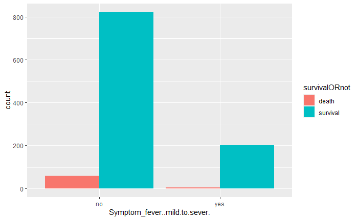

```r
ggplot(c19exploreData, aes(Symptom_fever..mild.to.sever., ..count..)) + geom_bar(aes(fill = survivalORnot), position = "dodge")
```

```r
CrossTable(x=Symptom_coughing..mild.to.sever., y=survivalORnot, chisq = TRUE)
```

```
   Cell Contents
|-------------------------|
|                       N |
| Chi-square contribution |
|           N / Row Total |
|           N / Col Total |
|         N / Table Total |
|-------------------------|


Total Observations in Table:  1085


                                 | survivalORnot
Symptom_coughing..mild.to.sever. |     death |  survival | Row Total |
---------------------------------|-----------|-----------|-----------|
                              no |        59 |       910 |       969 |
                                 |     0.133 |     0.008 |           |
                                 |     0.061 |     0.939 |     0.893 |
                                 |     0.937 |     0.890 |           |
                                 |     0.054 |     0.839 |           |
---------------------------------|-----------|-----------|-----------|
                             yes |         4 |       112 |       116 |
                                 |     1.111 |     0.068 |           |
                                 |     0.034 |     0.966 |     0.107 |
                                 |     0.063 |     0.110 |           |
                                 |     0.004 |     0.103 |           |
---------------------------------|-----------|-----------|-----------|
                    Column Total |        63 |      1022 |      1085 |
                                 |     0.058 |     0.942 |           |
---------------------------------|-----------|-----------|-----------|


Statistics for All Table Factors


Pearson's Chi-squared test
------------------------------------------------------------
Chi^2 =  1.32064     d.f. =  1     p =  0.2504773

Pearson's Chi-squared test with Yates' continuity correction
------------------------------------------------------------
Chi^2 =  0.8819807     d.f. =  1     p =  0.3476598
```

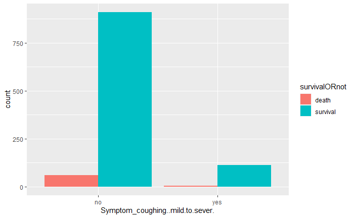

```r
ggplot(c19exploreData, aes(Symptom_coughing..mild.to.sever., ..count..)) + geom_bar(aes(fill = survivalORnot), position = "dodge")
```

```r
CrossTable(x=Symptom_difficulty.breathing, y=survivalORnot, chisq = TRUE)
```

```
Chi-squared approximation may be incorrectChi-squared approximation may be incorrect
```

```
   Cell Contents
|-------------------------|
|                       N |
| Chi-square contribution |
|           N / Row Total |
|           N / Col Total |
|         N / Table Total |
|-------------------------|


Total Observations in Table:  1085


                             | survivalORnot
Symptom_difficulty.breathing |     death |  survival | Row Total |
-----------------------------|-----------|-----------|-----------|
                          no |        62 |      1018 |      1080 |
                             |     0.008 |     0.000 |           |
                             |     0.057 |     0.943 |     0.995 |
                             |     0.984 |     0.996 |           |
                             |     0.057 |     0.938 |           |
-----------------------------|-----------|-----------|-----------|
                         yes |         1 |         4 |         5 |
                             |     1.735 |     0.107 |           |
                             |     0.200 |     0.800 |     0.005 |
                             |     0.016 |     0.004 |           |
                             |     0.001 |     0.004 |           |
-----------------------------|-----------|-----------|-----------|
                Column Total |        63 |      1022 |      1085 |
                             |     0.058 |     0.942 |           |
-----------------------------|-----------|-----------|-----------|


Statistics for All Table Factors


Pearson's Chi-squared test
------------------------------------------------------------
Chi^2 =  1.850231     d.f. =  1     p =  0.1737565

Pearson's Chi-squared test with Yates' continuity correction
------------------------------------------------------------
Chi^2 =  0.1615129     d.f. =  1     p =  0.6877674
```

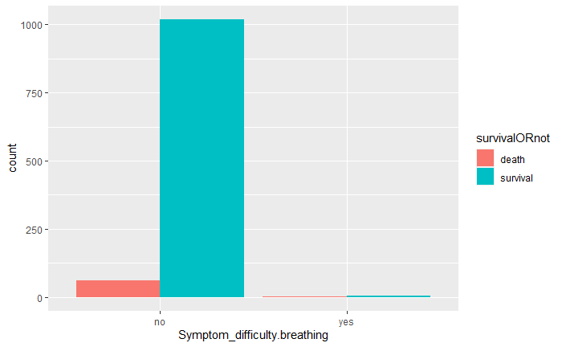

```r
ggplot(c19exploreData, aes(Symptom_difficulty.breathing, ..count..)) + geom_bar(aes(fill = survivalORnot), position = "dodge")
```

```r
CrossTable(x=Symptom_chills, y=survivalORnot, chisq = TRUE)
```

```
Chi-squared approximation may be incorrectChi-squared approximation may be incorrect
```

```
   Cell Contents
|-------------------------|
|                       N |
| Chi-square contribution |
|           N / Row Total |
|           N / Col Total |
|         N / Table Total |
|-------------------------|


Total Observations in Table:  1085


               | survivalORnot
Symptom_chills |     death |  survival | Row Total |
---------------|-----------|-----------|-----------|
            no |        63 |      1008 |      1071 |
               |     0.011 |     0.001 |           |
               |     0.059 |     0.941 |     0.987 |
               |     1.000 |     0.986 |           |
               |     0.058 |     0.929 |           |
---------------|-----------|-----------|-----------|
           yes |         0 |        14 |        14 |
               |     0.813 |     0.050 |           |
               |     0.000 |     1.000 |     0.013 |
               |     0.000 |     0.014 |           |
               |     0.000 |     0.013 |           |
---------------|-----------|-----------|-----------|
  Column Total |        63 |      1022 |      1085 |
               |     0.058 |     0.942 |           |
---------------|-----------|-----------|-----------|


Statistics for All Table Factors


Pearson's Chi-squared test
------------------------------------------------------------
Chi^2 =  0.8742949     d.f. =  1     p =  0.349769

Pearson's Chi-squared test with Yates' continuity correction
------------------------------------------------------------
Chi^2 =  0.1295389     d.f. =  1     p =  0.7189106
```

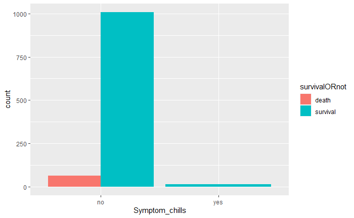

```r
ggplot(c19exploreData, aes(Symptom_chills, ..count..)) + geom_bar(aes(fill = survivalORnot), position = "dodge")
```

```r
CrossTable(x=Symptom_joint.pain, y=survivalORnot, chisq = TRUE)
```

```
Chi-squared approximation may be incorrectChi-squared approximation may be incorrect
```

```
   Cell Contents
|-------------------------|
|                       N |
| Chi-square contribution |
|           N / Row Total |
|           N / Col Total |
|         N / Table Total |
|-------------------------|


Total Observations in Table:  1085


                   | survivalORnot
Symptom_joint.pain |     death |  survival | Row Total |
-------------------|-----------|-----------|-----------|
                no |        63 |      1013 |      1076 |
                   |     0.004 |     0.000 |           |
                   |     0.059 |     0.941 |     0.992 |
                   |     1.000 |     0.991 |           |
                   |     0.058 |     0.934 |           |
-------------------|-----------|-----------|-----------|
               yes |         0 |         9 |         9 |
                   |     0.523 |     0.032 |           |
                   |     0.000 |     1.000 |     0.008 |
                   |     0.000 |     0.009 |           |
                   |     0.000 |     0.008 |           |
-------------------|-----------|-----------|-----------|
      Column Total |        63 |      1022 |      1085 |
                   |     0.058 |     0.942 |           |
-------------------|-----------|-----------|-----------|


Statistics for All Table Factors


Pearson's Chi-squared test
------------------------------------------------------------
Chi^2 =  0.559435     d.f. =  1     p =  0.454488

Pearson's Chi-squared test with Yates' continuity correction
------------------------------------------------------------
Chi^2 =  0.001044517     d.f. =  1     p =  0.9742177
```

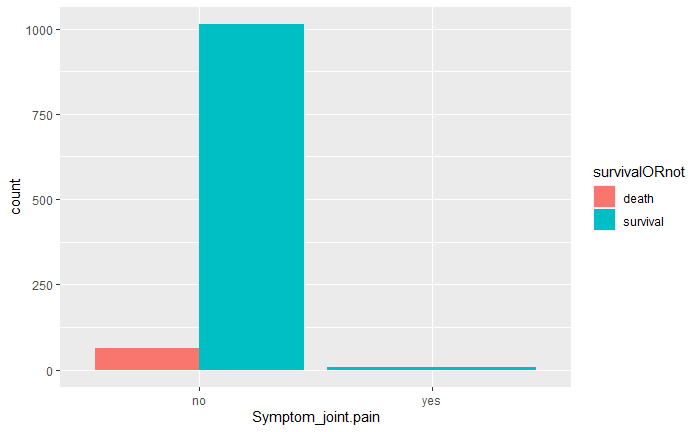

```r
ggplot(c19exploreData, aes(Symptom_joint.pain, ..count..)) + geom_bar(aes(fill = survivalORnot), position = "dodge")
```

```r
CrossTable(x=Symptom_throat.pain, y=survivalORnot, chisq = TRUE)
```

```
Chi-squared approximation may be incorrectChi-squared approximation may be incorrect
```

```
   Cell Contents
|-------------------------|
|                       N |
| Chi-square contribution |
|           N / Row Total |
|           N / Col Total |
|         N / Table Total |
|-------------------------|


Total Observations in Table:  1085


                    | survivalORnot
Symptom_throat.pain |     death |  survival | Row Total |
--------------------|-----------|-----------|-----------|
                 no |        63 |      1020 |      1083 |
                    |     0.000 |     0.000 |           |
                    |     0.058 |     0.942 |     0.998 |
                    |     1.000 |     0.998 |           |
                    |     0.058 |     0.940 |           |
--------------------|-----------|-----------|-----------|
                yes |         0 |         2 |         2 |
                    |     0.116 |     0.007 |           |
                    |     0.000 |     1.000 |     0.002 |
                    |     0.000 |     0.002 |           |
                    |     0.000 |     0.002 |           |
--------------------|-----------|-----------|-----------|
       Column Total |        63 |      1022 |      1085 |
                    |     0.058 |     0.942 |           |
--------------------|-----------|-----------|-----------|


Statistics for All Table Factors


Pearson's Chi-squared test
------------------------------------------------------------
Chi^2 =  0.1235153     d.f. =  1     p =  0.7252526

Pearson's Chi-squared test with Yates' continuity correction
------------------------------------------------------------
Chi^2 =  8.086711e-32     d.f. =  1     p =  1
```

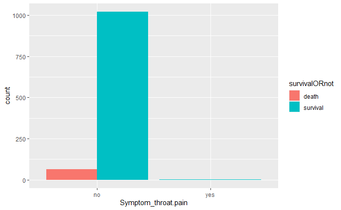

```r
ggplot(c19exploreData, aes(Symptom_throat.pain, ..count..)) + geom_bar(aes(fill = survivalORnot), position = "dodge")
```

```r
CrossTable(x=Symptom_nasal.discharge, y=survivalORnot, chisq = TRUE)
```

```
Chi-squared approximation may be incorrectChi-squared approximation may be incorrect
```

```
   Cell Contents
|-------------------------|
|                       N |
| Chi-square contribution |
|           N / Row Total |
|           N / Col Total |
|         N / Table Total |
|-------------------------|


Total Observations in Table:  1085


                        | survivalORnot
Symptom_nasal.discharge |     death |  survival | Row Total |
------------------------|-----------|-----------|-----------|
                     no |        63 |      1010 |      1073 |
                        |     0.008 |     0.000 |           |
                        |     0.059 |     0.941 |     0.989 |
                        |     1.000 |     0.988 |           |
                        |     0.058 |     0.931 |           |
------------------------|-----------|-----------|-----------|
                    yes |         0 |        12 |        12 |
                        |     0.697 |     0.043 |           |
                        |     0.000 |     1.000 |     0.011 |
                        |     0.000 |     0.012 |           |
                        |     0.000 |     0.011 |           |
------------------------|-----------|-----------|-----------|
           Column Total |        63 |      1022 |      1085 |
                        |     0.058 |     0.942 |           |
------------------------|-----------|-----------|-----------|


Statistics for All Table Factors


Pearson's Chi-squared test
------------------------------------------------------------
Chi^2 =  0.7479988     d.f. =  1     p =  0.3871106

Pearson's Chi-squared test with Yates' continuity correction
------------------------------------------------------------
Chi^2 =  0.05965586     d.f. =  1     p =  0.8070407
```

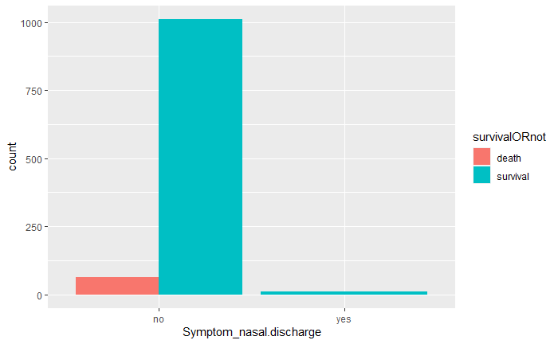

```r
ggplot(c19exploreData, aes(Symptom_nasal.discharge, ..count..)) + geom_bar(aes(fill = survivalORnot), position = "dodge")
```

```r
CrossTable(x=Symptom_fatigue, y=survivalORnot, chisq = TRUE)
```

```
Chi-squared approximation may be incorrectChi-squared approximation may be incorrect
```

```
   Cell Contents
|-------------------------|
|                       N |
| Chi-square contribution |
|           N / Row Total |
|           N / Col Total |
|         N / Table Total |
|-------------------------|


Total Observations in Table:  1085


                | survivalORnot
Symptom_fatigue |     death |  survival | Row Total |
----------------|-----------|-----------|-----------|
             no |        62 |      1011 |      1073 |
                |     0.001 |     0.000 |           |
                |     0.058 |     0.942 |     0.989 |
                |     0.984 |     0.989 |           |
                |     0.057 |     0.932 |           |
----------------|-----------|-----------|-----------|
            yes |         1 |        11 |        12 |
                |     0.132 |     0.008 |           |
                |     0.083 |     0.917 |     0.011 |
                |     0.016 |     0.011 |           |
                |     0.001 |     0.010 |           |
----------------|-----------|-----------|-----------|
   Column Total |        63 |      1022 |      1085 |
                |     0.058 |     0.942 |           |
----------------|-----------|-----------|-----------|


Statistics for All Table Factors


Pearson's Chi-squared test
------------------------------------------------------------
Chi^2 =  0.1416606     d.f. =  1     p =  0.7066357

Pearson's Chi-squared test with Yates' continuity correction
------------------------------------------------------------
Chi^2 =  3.606019e-27     d.f. =  1     p =  1
```

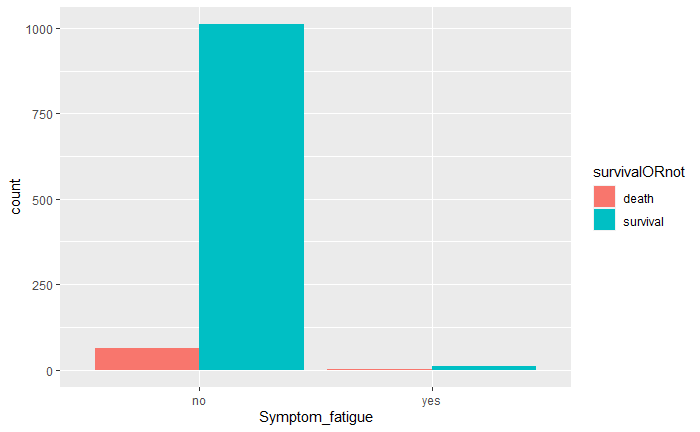

```r
ggplot(c19exploreData, aes(Symptom_fatigue, ..count..)) + geom_bar(aes(fill = survivalORnot), position = "dodge")
```

```r
CrossTable(x=Symptom_abdominal.pain, y=survivalORnot, chisq = TRUE)
```

```
Chi-squared approximation may be incorrectChi-squared approximation may be incorrect
```

```
   Cell Contents
|-------------------------|
|                       N |
| Chi-square contribution |
|           N / Row Total |
|           N / Col Total |
|         N / Table Total |
|-------------------------|


Total Observations in Table:  1085


                       | survivalORnot
Symptom_abdominal.pain |     death |  survival | Row Total |
-----------------------|-----------|-----------|-----------|
                    no |        63 |      1021 |      1084 |
                       |     0.000 |     0.000 |           |
                       |     0.058 |     0.942 |     0.999 |
                       |     1.000 |     0.999 |           |
                       |     0.058 |     0.941 |           |
-----------------------|-----------|-----------|-----------|
                   yes |         0 |         1 |         1 |
                       |     0.058 |     0.004 |           |
                       |     0.000 |     1.000 |     0.001 |
                       |     0.000 |     0.001 |           |
                       |     0.000 |     0.001 |           |
-----------------------|-----------|-----------|-----------|
          Column Total |        63 |      1022 |      1085 |
                       |     0.058 |     0.942 |           |
-----------------------|-----------|-----------|-----------|


Statistics for All Table Factors


Pearson's Chi-squared test
------------------------------------------------------------
Chi^2 =  0.0617007     d.f. =  1     p =  0.8038278

Pearson's Chi-squared test with Yates' continuity correction
------------------------------------------------------------
Chi^2 =  5.103871e-26     d.f. =  1     p =  1
```

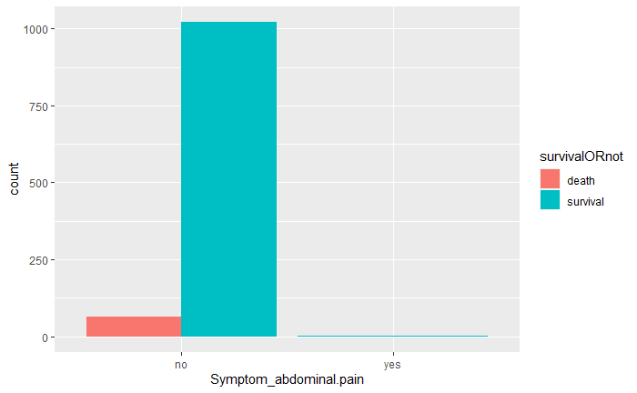

```r
ggplot(c19exploreData, aes(Symptom_abdominal.pain, ..count..)) + geom_bar(aes(fill = survivalORnot), position = "dodge")
```

```r
CrossTable(x=Symptom_diarrhea, y=survivalORnot, chisq = TRUE)
```

```
Chi-squared approximation may be incorrectChi-squared approximation may be incorrect
```

```
   Cell Contents
|-------------------------|
|                       N |
| Chi-square contribution |
|           N / Row Total |
|           N / Col Total |
|         N / Table Total |
|-------------------------|


Total Observations in Table:  1085


                 | survivalORnot
Symptom_diarrhea |     death |  survival | Row Total |
-----------------|-----------|-----------|-----------|
              no |        63 |      1012 |      1075 |
                 |     0.005 |     0.000 |           |
                 |     0.059 |     0.941 |     0.991 |
                 |     1.000 |     0.990 |           |
                 |     0.058 |     0.933 |           |
-----------------|-----------|-----------|-----------|
             yes |         0 |        10 |        10 |
                 |     0.581 |     0.036 |           |
                 |     0.000 |     1.000 |     0.009 |
                 |     0.000 |     0.010 |           |
                 |     0.000 |     0.009 |           |
-----------------|-----------|-----------|-----------|
    Column Total |        63 |      1022 |      1085 |
                 |     0.058 |     0.942 |           |
-----------------|-----------|-----------|-----------|


Statistics for All Table Factors


Pearson's Chi-squared test
------------------------------------------------------------
Chi^2 =  0.6221727     d.f. =  1     p =  0.4302411

Pearson's Chi-squared test with Yates' continuity correction
------------------------------------------------------------
Chi^2 =  0.01200179     d.f. =  1     p =  0.9127641
```

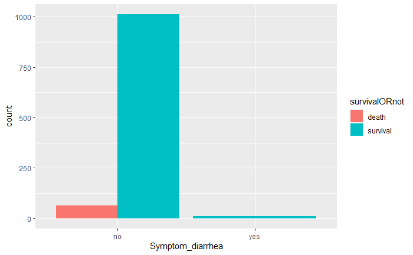

```r
ggplot(c19exploreData, aes(Symptom_diarrhea, ..count..)) + geom_bar(aes(fill = survivalORnot), position = "dodge")
```

```r
CrossTable(x=Symptom_cold, y=survivalORnot, chisq = TRUE)
```

```
Chi-squared approximation may be incorrectChi-squared approximation may be incorrect
```

```
   Cell Contents
|-------------------------|
|                       N |
| Chi-square contribution |
|           N / Row Total |
|           N / Col Total |
|         N / Table Total |
|-------------------------|


Total Observations in Table:  1085


             | survivalORnot
Symptom_cold |     death |  survival | Row Total |
-------------|-----------|-----------|-----------|
          no |        62 |      1021 |      1083 |
             |     0.012 |     0.001 |           |
             |     0.057 |     0.943 |     0.998 |
             |     0.984 |     0.999 |           |
             |     0.057 |     0.941 |           |
-------------|-----------|-----------|-----------|
         yes |         1 |         1 |         2 |
             |     6.727 |     0.415 |           |
             |     0.500 |     0.500 |     0.002 |
             |     0.016 |     0.001 |           |
             |     0.001 |     0.001 |           |
-------------|-----------|-----------|-----------|
Column Total |        63 |      1022 |      1085 |
             |     0.058 |     0.942 |           |
-------------|-----------|-----------|-----------|


Statistics for All Table Factors


Pearson's Chi-squared test
------------------------------------------------------------
Chi^2 =  7.155122     d.f. =  1     p =  0.00747502

Pearson's Chi-squared test with Yates' continuity correction
------------------------------------------------------------
Chi^2 =  1.349615     d.f. =  1     p =  0.2453455
```

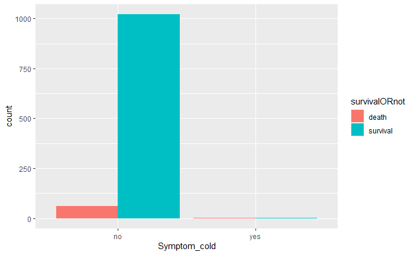

```r
ggplot(c19exploreData, aes(Symptom_cold, ..count..)) + geom_bar(aes(fill = survivalORnot), position = "dodge")
```

```r
CrossTable(x=Symptom_pneumonia, y=survivalORnot, chisq = TRUE)
```

```
Chi-squared approximation may be incorrectChi-squared approximation may be incorrect
```

```
   Cell Contents
|-------------------------|
|                       N |
| Chi-square contribution |
|           N / Row Total |
|           N / Col Total |
|         N / Table Total |
|-------------------------|


Total Observations in Table:  1085


                  | survivalORnot
Symptom_pneumonia |     death |  survival | Row Total |
------------------|-----------|-----------|-----------|
               no |        61 |      1021 |      1082 |
                  |     0.053 |     0.003 |           |
                  |     0.056 |     0.944 |     0.997 |
                  |     0.968 |     0.999 |           |
                  |     0.056 |     0.941 |           |
------------------|-----------|-----------|-----------|
              yes |         2 |         1 |         3 |
                  |    19.137 |     1.180 |           |
                  |     0.667 |     0.333 |     0.003 |
                  |     0.032 |     0.001 |           |
                  |     0.002 |     0.001 |           |
------------------|-----------|-----------|-----------|
     Column Total |        63 |      1022 |      1085 |
                  |     0.058 |     0.942 |           |
------------------|-----------|-----------|-----------|


Statistics for All Table Factors


Pearson's Chi-squared test
------------------------------------------------------------
Chi^2 =  20.37318     d.f. =  1     p =  6.371671e-06

Pearson's Chi-squared test with Yates' continuity correction
------------------------------------------------------------
Chi^2 =  10.7426     d.f. =  1     p =  0.00104697
```

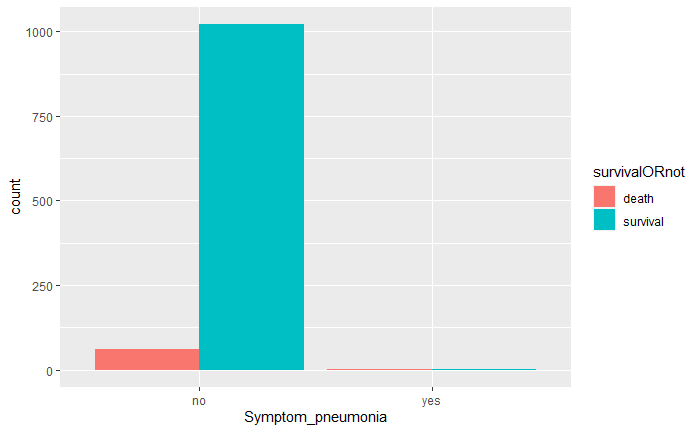

```r
ggplot(c19exploreData, aes(Symptom_pneumonia, ..count..)) + geom_bar(aes(fill = survivalORnot), position = "dodge")
```

```r
CrossTable(x=Symptom_vomiting, y=survivalORnot, chisq = TRUE)
```

```
Chi-squared approximation may be incorrectChi-squared approximation may be incorrect
```

```
   Cell Contents
|-------------------------|
|                       N |
| Chi-square contribution |
|           N / Row Total |
|           N / Col Total |
|         N / Table Total |
|-------------------------|


Total Observations in Table:  1085


                 | survivalORnot
Symptom_vomiting |     death |  survival | Row Total |
-----------------|-----------|-----------|-----------|
              no |        63 |      1016 |      1079 |
                 |     0.002 |     0.000 |           |
                 |     0.058 |     0.942 |     0.994 |
                 |     1.000 |     0.994 |           |
                 |     0.058 |     0.936 |           |
-----------------|-----------|-----------|-----------|
             yes |         0 |         6 |         6 |
                 |     0.348 |     0.021 |           |
                 |     0.000 |     1.000 |     0.006 |
                 |     0.000 |     0.006 |           |
                 |     0.000 |     0.006 |           |
-----------------|-----------|-----------|-----------|
    Column Total |        63 |      1022 |      1085 |
                 |     0.058 |     0.942 |           |
-----------------|-----------|-----------|-----------|


Statistics for All Table Factors


Pearson's Chi-squared test
------------------------------------------------------------
Chi^2 =  0.3719197     d.f. =  1     p =  0.5419597

Pearson's Chi-squared test with Yates' continuity correction
------------------------------------------------------------
Chi^2 =  7.180748e-31     d.f. =  1     p =  1
```

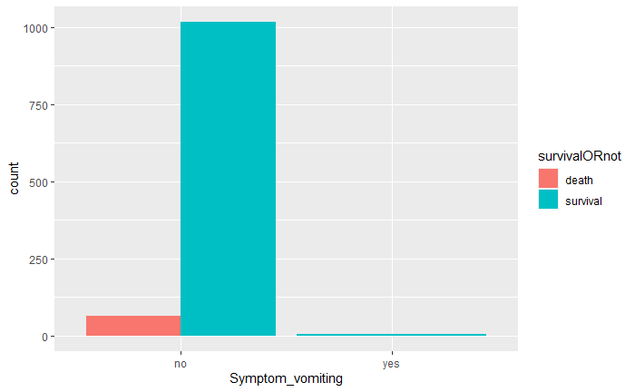

```r
ggplot(c19exploreData, aes(Symptom_vomiting, ..count..)) + geom_bar(aes(fill = survivalORnot), position = "dodge")
```

```r
CrossTable(x=Symptom_loss.of.appetite , y=survivalORnot, chisq = TRUE)
```

```
Chi-squared approximation may be incorrectChi-squared approximation may be incorrect
```

```
   Cell Contents
|-------------------------|
|                       N |
| Chi-square contribution |
|           N / Row Total |
|           N / Col Total |
|         N / Table Total |
|-------------------------|


Total Observations in Table:  1085


                         | survivalORnot
Symptom_loss.of.appetite |     death |  survival | Row Total |
-------------------------|-----------|-----------|-----------|
                      no |        63 |      1020 |      1083 |
                         |     0.000 |     0.000 |           |
                         |     0.058 |     0.942 |     0.998 |
                         |     1.000 |     0.998 |           |
                         |     0.058 |     0.940 |           |
-------------------------|-----------|-----------|-----------|
                     yes |         0 |         2 |         2 |
                         |     0.116 |     0.007 |           |
                         |     0.000 |     1.000 |     0.002 |
                         |     0.000 |     0.002 |           |
                         |     0.000 |     0.002 |           |
-------------------------|-----------|-----------|-----------|
            Column Total |        63 |      1022 |      1085 |
                         |     0.058 |     0.942 |           |
-------------------------|-----------|-----------|-----------|


Statistics for All Table Factors


Pearson's Chi-squared test
------------------------------------------------------------
Chi^2 =  0.1235153     d.f. =  1     p =  0.7252526

Pearson's Chi-squared test with Yates' continuity correction
------------------------------------------------------------
Chi^2 =  8.086711e-32     d.f. =  1     p =  1
```

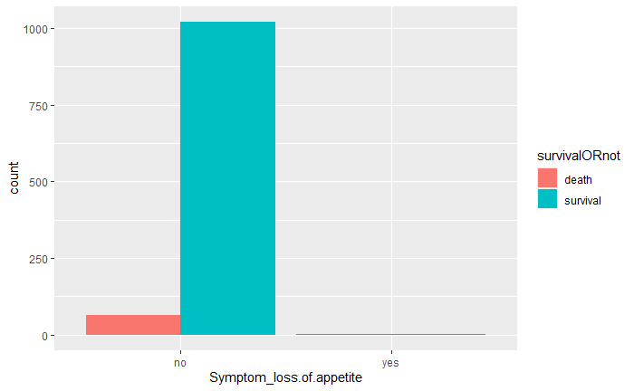

```r
ggplot(c19exploreData, aes(Symptom_loss.of.appetite , ..count..)) + geom_bar(aes(fill = survivalORnot), position = "dodge")
```

```r
CrossTable(x=Symptom_malaise , y=survivalORnot, chisq = TRUE)
```

```
Chi-squared approximation may be incorrectChi-squared approximation may be incorrect
```

```
   Cell Contents
|-------------------------|
|                       N |
| Chi-square contribution |
|           N / Row Total |
|           N / Col Total |
|         N / Table Total |
|-------------------------|


Total Observations in Table:  1085


                | survivalORnot
Symptom_malaise |     death |  survival | Row Total |
----------------|-----------|-----------|-----------|
             no |        63 |       994 |      1057 |
                |     0.043 |     0.003 |           |
                |     0.060 |     0.940 |     0.974 |
                |     1.000 |     0.973 |           |
                |     0.058 |     0.916 |           |
----------------|-----------|-----------|-----------|
            yes |         0 |        28 |        28 |
                |     1.626 |     0.100 |           |
                |     0.000 |     1.000 |     0.026 |
                |     0.000 |     0.027 |           |
                |     0.000 |     0.026 |           |
----------------|-----------|-----------|-----------|
   Column Total |        63 |      1022 |      1085 |
                |     0.058 |     0.942 |           |
----------------|-----------|-----------|-----------|


Statistics for All Table Factors


Pearson's Chi-squared test
------------------------------------------------------------
Chi^2 =  1.77175     d.f. =  1     p =  0.1831657

Pearson's Chi-squared test with Yates' continuity correction
------------------------------------------------------------
Chi^2 =  0.8495564     d.f. =  1     p =  0.3566779
```

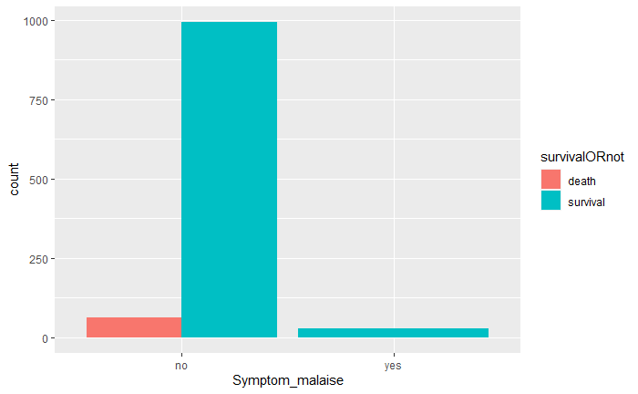

```r
ggplot(c19exploreData, aes(Symptom_malaise , ..count..)) + geom_bar(aes(fill = survivalORnot), position = "dodge")
```

```r
CrossTable(x=Symptom_headache , y=survivalORnot, chisq = TRUE)
```

```
Chi-squared approximation may be incorrectChi-squared approximation may be incorrect
```

```
   Cell Contents
|-------------------------|
|                       N |
| Chi-square contribution |
|           N / Row Total |
|           N / Col Total |
|         N / Table Total |
|-------------------------|


Total Observations in Table:  1085


                 | survivalORnot
Symptom_headache |     death |  survival | Row Total |
-----------------|-----------|-----------|-----------|
              no |        63 |      1006 |      1069 |
                 |     0.014 |     0.001 |           |
                 |     0.059 |     0.941 |     0.985 |
                 |     1.000 |     0.984 |           |
                 |     0.058 |     0.927 |           |
-----------------|-----------|-----------|-----------|
             yes |         0 |        16 |        16 |
                 |     0.929 |     0.057 |           |
                 |     0.000 |     1.000 |     0.015 |
                 |     0.000 |     0.016 |           |
                 |     0.000 |     0.015 |           |
-----------------|-----------|-----------|-----------|
    Column Total |        63 |      1022 |      1085 |
                 |     0.058 |     0.942 |           |
-----------------|-----------|-----------|-----------|


Statistics for All Table Factors


Pearson's Chi-squared test
------------------------------------------------------------
Chi^2 =  1.001064     d.f. =  1     p =  0.3170533

Pearson's Chi-squared test with Yates' continuity correction
------------------------------------------------------------
Chi^2 =  0.2134912     d.f. =  1     p =  0.6440447
```

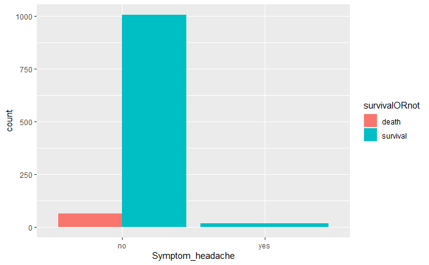

```r
ggplot(c19exploreData, aes(Symptom_headache , ..count..)) + geom_bar(aes(fill = survivalORnot), position = "dodge")
```

```r
CrossTable(x=Symptom_sputum , y=survivalORnot, chisq = TRUE)
```

```
Chi-squared approximation may be incorrectChi-squared approximation may be incorrect
```

```
   Cell Contents
|-------------------------|
|                       N |
| Chi-square contribution |
|           N / Row Total |
|           N / Col Total |
|         N / Table Total |
|-------------------------|


Total Observations in Table:  1085


               | survivalORnot
Symptom_sputum |     death |  survival | Row Total |
---------------|-----------|-----------|-----------|
            no |        63 |      1011 |      1074 |
               |     0.007 |     0.000 |           |
               |     0.059 |     0.941 |     0.990 |
               |     1.000 |     0.989 |           |
               |     0.058 |     0.932 |           |
---------------|-----------|-----------|-----------|
           yes |         0 |        11 |        11 |
               |     0.639 |     0.039 |           |
               |     0.000 |     1.000 |     0.010 |
               |     0.000 |     0.011 |           |
               |     0.000 |     0.010 |           |
---------------|-----------|-----------|-----------|
  Column Total |        63 |      1022 |      1085 |
               |     0.058 |     0.942 |           |
---------------|-----------|-----------|-----------|


Statistics for All Table Factors


Pearson's Chi-squared test
------------------------------------------------------------
Chi^2 =  0.6850272     d.f. =  1     p =  0.407861

Pearson's Chi-squared test with Yates' continuity correction
------------------------------------------------------------
Chi^2 =  0.03230832     d.f. =  1     p =  0.8573527
```

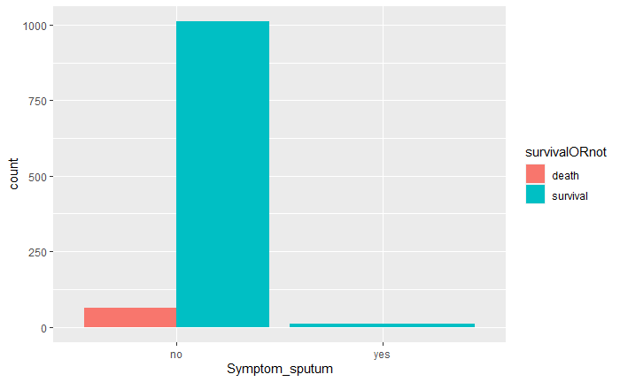

```r
ggplot(c19exploreData, aes(Symptom_sputum , ..count..)) + geom_bar(aes(fill = survivalORnot), position = "dodge")
```

```r
CrossTable(x=Symptom_myalgia, y=survivalORnot, chisq = TRUE)
```

```
Chi-squared approximation may be incorrectChi-squared approximation may be incorrect
```

```
   Cell Contents
|-------------------------|
|                       N |
| Chi-square contribution |
|           N / Row Total |
|           N / Col Total |
|         N / Table Total |
|-------------------------|


Total Observations in Table:  1085


                | survivalORnot
Symptom_myalgia |     death |  survival | Row Total |
----------------|-----------|-----------|-----------|
             no |        62 |      1012 |      1074 |
                |     0.002 |     0.000 |           |
                |     0.058 |     0.942 |     0.990 |
                |     0.984 |     0.990 |           |
                |     0.057 |     0.933 |           |
----------------|-----------|-----------|-----------|
            yes |         1 |        10 |        11 |
                |     0.204 |     0.013 |           |
                |     0.091 |     0.909 |     0.010 |
                |     0.016 |     0.010 |           |
                |     0.001 |     0.009 |           |
----------------|-----------|-----------|-----------|
   Column Total |        63 |      1022 |      1085 |
                |     0.058 |     0.942 |           |
----------------|-----------|-----------|-----------|


Statistics for All Table Factors


Pearson's Chi-squared test
------------------------------------------------------------
Chi^2 =  0.2191863     d.f. =  1     p =  0.6396606

Pearson's Chi-squared test with Yates' continuity correction
------------------------------------------------------------
Chi^2 =  5.444508e-30     d.f. =  1     p =  1
```

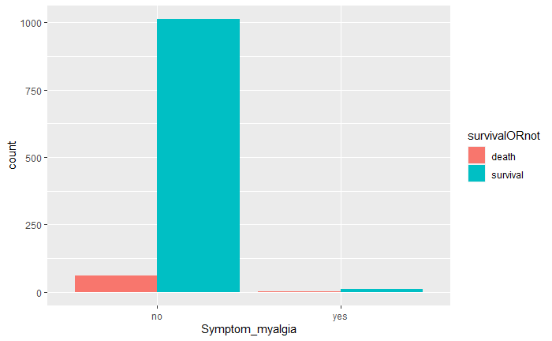

```r
ggplot(c19exploreData, aes(Symptom_myalgia, ..count..)) + geom_bar(aes(fill = survivalORnot), position = "dodge")
```

```r
CrossTable(x=Symptom_sore.throat, y=survivalORnot, chisq = TRUE)
```

```
Chi-squared approximation may be incorrectChi-squared approximation may be incorrect
```

```
   Cell Contents
|-------------------------|
|                       N |
| Chi-square contribution |
|           N / Row Total |
|           N / Col Total |
|         N / Table Total |
|-------------------------|


Total Observations in Table:  1085


                    | survivalORnot
Symptom_sore.throat |     death |  survival | Row Total |
--------------------|-----------|-----------|-----------|
                 no |        62 |       995 |      1057 |
                    |     0.006 |     0.000 |           |
                    |     0.059 |     0.941 |     0.974 |
                    |     0.984 |     0.974 |           |
                    |     0.057 |     0.917 |           |
--------------------|-----------|-----------|-----------|
                yes |         1 |        27 |        28 |
                    |     0.241 |     0.015 |           |
                    |     0.036 |     0.964 |     0.026 |
                    |     0.016 |     0.026 |           |
                    |     0.001 |     0.025 |           |
--------------------|-----------|-----------|-----------|
       Column Total |        63 |      1022 |      1085 |
                    |     0.058 |     0.942 |           |
--------------------|-----------|-----------|-----------|


Statistics for All Table Factors


Pearson's Chi-squared test
------------------------------------------------------------
Chi^2 =  0.2625094     d.f. =  1     p =  0.6084014

Pearson's Chi-squared test with Yates' continuity correction
------------------------------------------------------------
Chi^2 =  0.01060891     d.f. =  1     p =  0.9179633
```

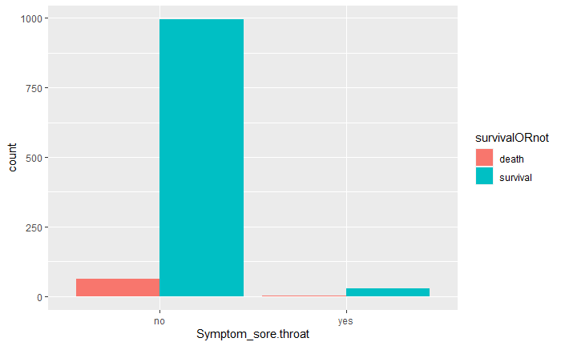

```r
ggplot(c19exploreData, aes(Symptom_sore.throat, ..count..)) + geom_bar(aes(fill = survivalORnot), position = "dodge")
```

```r
CrossTable(x=Symptom_dyspnea, y=survivalORnot, chisq = TRUE)
```

```
Chi-squared approximation may be incorrectChi-squared approximation may be incorrect
```

```
   Cell Contents
|-------------------------|
|                       N |
| Chi-square contribution |
|           N / Row Total |
|           N / Col Total |
|         N / Table Total |
|-------------------------|


Total Observations in Table:  1085


                | survivalORnot
Symptom_dyspnea |     death |  survival | Row Total |
----------------|-----------|-----------|-----------|
             no |        62 |      1008 |      1070 |
                |     0.000 |     0.000 |           |
                |     0.058 |     0.942 |     0.986 |
                |     0.984 |     0.986 |           |
                |     0.057 |     0.929 |           |
----------------|-----------|-----------|-----------|
            yes |         1 |        14 |        15 |
                |     0.019 |     0.001 |           |
                |     0.067 |     0.933 |     0.014 |
                |     0.016 |     0.014 |           |
                |     0.001 |     0.013 |           |
----------------|-----------|-----------|-----------|
   Column Total |        63 |      1022 |      1085 |
                |     0.058 |     0.942 |           |
----------------|-----------|-----------|-----------|


Statistics for All Table Factors


Pearson's Chi-squared test
------------------------------------------------------------
Chi^2 =  0.02057877     d.f. =  1     p =  0.8859324

Pearson's Chi-squared test with Yates' continuity correction
------------------------------------------------------------
Chi^2 =  1.711749e-29     d.f. =  1     p =  1
```

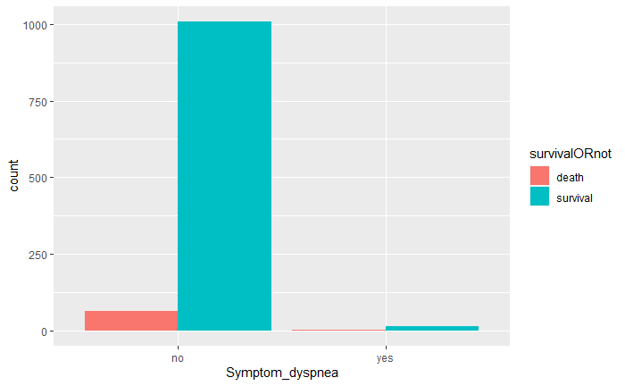

```r
ggplot(c19exploreData, aes(Symptom_dyspnea, ..count..)) + geom_bar(aes(fill = survivalORnot), position = "dodge")
```

```r
CrossTable(x=Symptom_nausea , y=survivalORnot, chisq = TRUE)
```

```
Chi-squared approximation may be incorrectChi-squared approximation may be incorrect
```

```
   Cell Contents
|-------------------------|
|                       N |
| Chi-square contribution |
|           N / Row Total |
|           N / Col Total |
|         N / Table Total |
|-------------------------|


Total Observations in Table:  1085


               | survivalORnot
Symptom_nausea |     death |  survival | Row Total |
---------------|-----------|-----------|-----------|
            no |        63 |      1020 |      1083 |
               |     0.000 |     0.000 |           |
               |     0.058 |     0.942 |     0.998 |
               |     1.000 |     0.998 |           |
               |     0.058 |     0.940 |           |
---------------|-----------|-----------|-----------|
           yes |         0 |         2 |         2 |
               |     0.116 |     0.007 |           |
               |     0.000 |     1.000 |     0.002 |
               |     0.000 |     0.002 |           |
               |     0.000 |     0.002 |           |
---------------|-----------|-----------|-----------|
  Column Total |        63 |      1022 |      1085 |
               |     0.058 |     0.942 |           |
---------------|-----------|-----------|-----------|


Statistics for All Table Factors


Pearson's Chi-squared test
------------------------------------------------------------
Chi^2 =  0.1235153     d.f. =  1     p =  0.7252526

Pearson's Chi-squared test with Yates' continuity correction
------------------------------------------------------------
Chi^2 =  8.086711e-32     d.f. =  1     p =  1
```

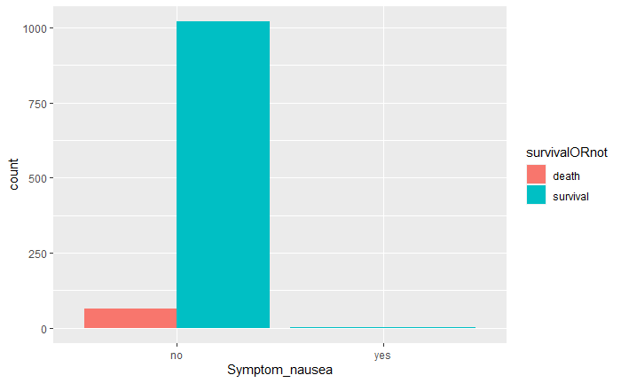

```r
ggplot(c19exploreData, aes(Symptom_nausea , ..count..)) + geom_bar(aes(fill = survivalORnot), position = "dodge")
```